# Getting Started with R

Pol Mayolas

2019-10-09

# Uploading Cars Data Set

First of all we uploaded Cars Data Set which have 3 variables with 50 observations on each one. You can import data sets using code directly or importing it form RStudio. We used the second option as it is easier, faster and more easy to configure parameters.

```r
library("readr")
library(ggplot2)
cars <- read.csv("~/Desktop/UBIQUM/Data Analytics 2/Get Started with R/R Tutorial Data Sets/cars.csv")
```

| name.of.car | speed.of.car | distance.of.car |
| --- | --- | --- |
| Ford | 4 | 2 |
| Jeep | 4 | 4 |
| Honda | 7 | 10 |
| KIA | 7 | 10 |
| Toyota | 8 | 14 |
| BMW | 9 | 16 |
| Mercedes | 10 | 17 |
| GM | 10 | 18 |
| Hyundai | 10 | 20 |
| Infiniti | 11 | 20 |
| Land Rover | 11 | 22 |
| Lexus | 12 | 24 |
| Mazda | 12 | 26 |
| Mitsubishi | 12 | 26 |
| Nissan | 12 | 26 |
| GMC | 13 | 26 |
| Fiat | 13 | 28 |
| Chrysler | 13 | 28 |
| Dodge | 13 | 32 |
| Acura | 14 | 32 |
| Audi | 14 | 32 |
| Chevrolet | 14 | 34 |
| Buick | 14 | 34 |
| Ford | 15 | 34 |
| Jeep | 15 | 36 |
| Honda | 15 | 36 |
| KIA | 16 | 40 |
| Toyota | 16 | 40 |
| BMW | 17 | 42 |
| Mercedes | 17 | 46 |
| GM | 17 | 46 |
| Hyundai | 18 | 48 |
| Infiniti | 18 | 50 |
| Land Rover | 18 | 52 |
| Lexus | 18 | 54 |
| Mazda | 19 | 54 |
| Mitsubishi | 19 | 56 |
| Nissan | 19 | 56 |
| GMC | 20 | 60 |
| Fiat | 20 | 64 |
| Chrysler | 20 | 66 |
| Dodge | 20 | 68 |
| Acura | 20 | 70 |
| Audi | 22 | 76 |
| Chevrolet | 23 | 80 |
| Buick | 24 | 84 |
| Jeep | 24 | 85 |
| Honda | 24 | 92 |
| KIA | 24 | 93 |
| Dodge | 25 | 120 |

# Preprocessing the data

Before starting to analyse and to create the model, we did the process of cleaning the data. There were no errors or missing data in the data set. The only thing that we did was to change the attributes names with the next function.

```r
names(cars)<-c("Brand","Speed","Distance")
names(cars)
```

```
## [1] "Brand"    "Speed"    "Distance"
```

Seems useless, but this will help us avoid coding errors as we will be typing this words several times in R code and it helps that they are short words and without dots.

# Getting to know the data

R is great for doing graphs, and in this ScatterPlot (using ggplot package) we can see that there is a linear correlation between speed and distance. Thats is why we are going to use after a Linear Regression algorythm for creating our prediction model.

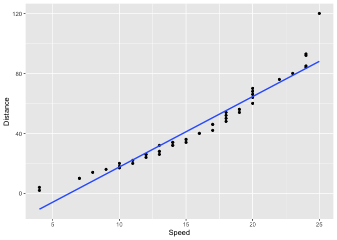

```r
ggplot(cars, aes(x = Speed, y = Distance)) + geom_point() + geom_smooth(method = "lm", se = F)
```

```r
summary(cars)
```

```
##      Brand        Speed         Distance
##  Dodge  : 3   Min.   : 4.0   Min.   :  2.00
##  Honda  : 3   1st Qu.:12.0   1st Qu.: 26.00
##  Jeep   : 3   Median :15.0   Median : 36.00
##  KIA    : 3   Mean   :15.4   Mean   : 42.98
##  Acura  : 2   3rd Qu.:19.0   3rd Qu.: 56.00
##  Audi   : 2   Max.   :25.0   Max.   :120.00
##  (Other):34
```

# Looking for Ouliers

Looking at the ScatterPlot we had the intuition that there could be some outliers that could afect our algorythm. So we used the best way to identify outliers creating boxplots for both attributes.

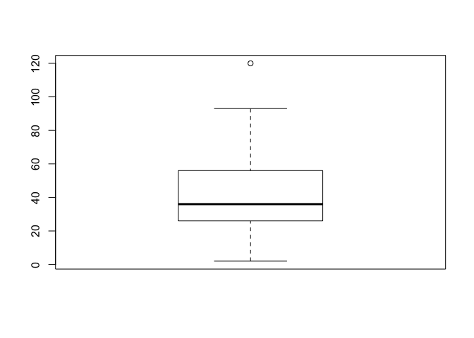

```r
boxplot(cars$Distance)
```

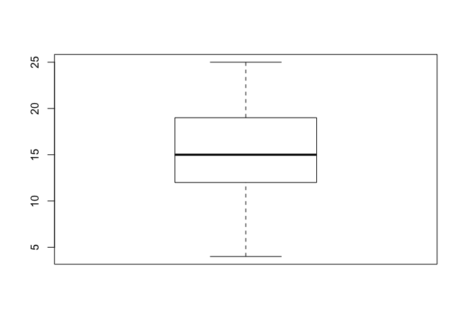

```r
boxplot(cars$Speed)
```

# Excluding Outliers

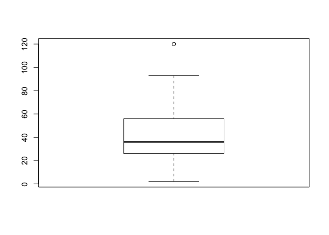

```r
box <- boxplot(cars$Distance)
```

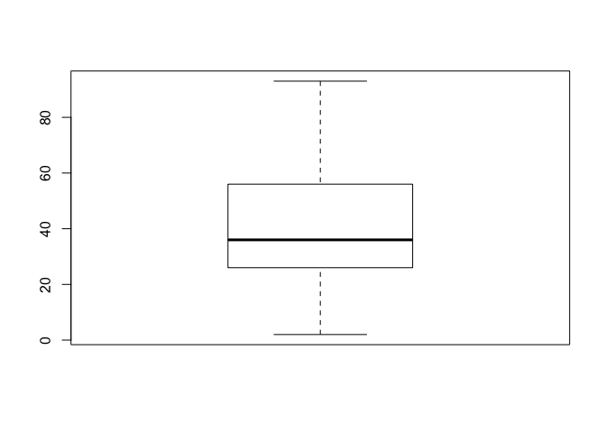

```r
cars2 <- cars[-which(cars$Distance == box$out) , ]

boxplot(cars2$Distance)
```

We then created another data set “cars2” for if we still need the original one for something. We prefer to have 2 different data sets, instead of doing changes on the original data set.

# Creating testing and training sets

## Data Set partition

```r
trainSize<-round(nrow(cars2)*0.7)
print(trainSize)
```

```
## [1] 34
```

```r
testSize<-nrow(cars2)-trainSize
print(testSize)
```

```
## [1] 15
```

## Creating the test set

```r
set.seed(1)
training_indices<- sample(seq_len(nrow(cars2)),size =trainSize)
print(training_indices)
```

```
##  [1]  4 39  1 34 23 43 14 18 33 21 40 10  7  9 15 48 25 44  5 31  2 38 41
## [24] 12 35 47 20  3  6 28 45 46 27 49
```

```r
trainSet<- cars2[training_indices, ]
testSet<- cars2[-training_indices, ]
print(testSet)
```

```
##         Brand Speed Distance
## 8          GM    10       18
## 11 Land Rover    11       22
## 13      Mazda    12       26
## 16        GMC    13       26
## 17       Fiat    13       28
## 19      Dodge    13       32
## 22  Chevrolet    14       34
## 24       Ford    15       34
## 26      Honda    15       36
## 29        BMW    17       42
## 30   Mercedes    17       46
## 32    Hyundai    18       48
## 36      Mazda    19       54
## 37 Mitsubishi    19       56
## 42      Dodge    20       68
```

# Creating Linear Regression Model

As we said before we are going to use a Linear Regression algorythm for our prediction model. Using the training set of data we see that our model called LRM is having trustable results, obtaining an Ajusted R-squared of 96%.

```r
LRM <- lm(Distance ~ Speed, trainSet)
summary(LRM)
```

```
##
## Call:
## lm(formula = Distance ~ Speed, data = trainSet)
##
## Residuals:
##    Min     1Q Median     3Q    Max
## -6.185 -4.282 -1.733  3.177 11.235
##
## Coefficients:
##             Estimate Std. Error t value Pr(>|t|)
## (Intercept) -25.0423     2.5570  -9.793 3.77e-11 ***
## Speed         4.4517     0.1566  28.421  < 2e-16 ***
## ---
## Signif. codes:  0 '***' 0.001 '**' 0.01 '*' 0.05 '.' 0.1 ' ' 1
##
## Residual standard error: 5.285 on 32 degrees of freedom
## Multiple R-squared:  0.9619, Adjusted R-squared:  0.9607
## F-statistic: 807.7 on 1 and 32 DF,  p-value: < 2.2e-16
```

# Prediction with Linear Regression Model

Time to use our model with the data that we reserved for testing.

```r
PredictionCars <- predict(LRM, testSet)
```

```r
knitr::kable(PredictionCars)
```

|  | x |
| --- | --- |
| 8 | 19.47483 |
| 11 | 23.92654 |
| 13 | 28.37824 |
| 16 | 32.82995 |
| 17 | 32.82995 |
| 19 | 32.82995 |
| 22 | 37.28166 |
| 24 | 41.73337 |
| 26 | 41.73337 |
| 29 | 50.63679 |
| 30 | 50.63679 |
| 32 | 55.08850 |
| 36 | 59.54021 |
| 37 | 59.54021 |
| 42 | 63.99191 |

```r
TestSetFinal <- cbind(testSet$Brand, testSet$Distance, PredictionCars)
knitr::kable(TestSetFinal)
```

|  |  |  | PredictionCars |
| --- | --- | --- | --- |
| 8 | 10 | 18 | 19.47483 |
| 11 | 17 | 22 | 23.92654 |
| 13 | 19 | 26 | 28.37824 |
| 16 | 11 | 26 | 32.82995 |
| 17 | 8 | 28 | 32.82995 |
| 19 | 7 | 32 | 32.82995 |
| 22 | 5 | 34 | 37.28166 |
| 24 | 9 | 34 | 41.73337 |
| 26 | 12 | 36 | 41.73337 |
| 29 | 3 | 42 | 50.63679 |
| 30 | 20 | 46 | 50.63679 |
| 32 | 13 | 48 | 55.08850 |
| 36 | 19 | 54 | 59.54021 |
| 37 | 21 | 56 | 59.54021 |
| 42 | 7 | 68 | 63.99191 |